# EP05

Grupo 9

2025-04-14

# Pregunta

## ¿Existen diferencias en el tiempo de resolución de cubos Megaminx entre participantes de Chile, Argentina y Perú?

Para dar respuesta a la pregunta planteada es indispensable formular las siguientes hipótesis:

Ho= Los tiempos de resolución promedio de los países Chile, Argentina y Perú son iguales para los cubos megaminx (μ_Chile= μ_Argentina= μ_Peru).

Ha= Los tiempos de resolución promedio para la resolución de cubos megaminx difiere para al menos uno de los países (∃i,j tal que μi!=μj)

En base a estas hipótesis se realizará la prueba ANOVA para muestras independientes, por lo cual, es necesario verificar el cumplimiento de las condiciones necesarias para llevar a cabo dicha prueba.

Empezando por la escala, dado que la variable dependiente es el tiempo, el cual, se mide en segundos, posee intervalos constantes sin importar dónde se ubique en la escala, cumpliendo así con la primera condición para aplicar la prueba de ANOVA.

Para la segunda condición de independencia, esta se cumple debido a que los datos extraídos pertenecen a distintas poblaciones según el país de los competidores.

En el caso de la condición de normalidad, a continuación se realizará un gráfico Q-Q por país para así evaluar la normalidad de los datos, no sin antes organziar los datos en formato largo y ancho:

```r
library(tidyr)
library(dplyr)
library(ggpubr)
```

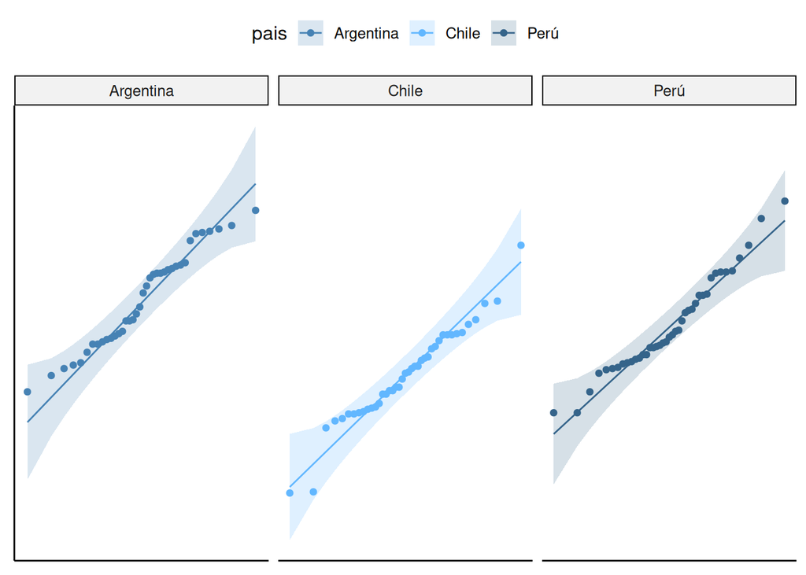

```r
library(ggplot2)

datos = read.csv2("EP05 Datos.csv")

datos_largo = datos %>%
  select(-X) %>%
  filter(pais %in% c("Perú", "Chile", "Argentina"), tipo == "Megaminx") %>%
  select(-tipo) %>%
  mutate(pais = factor(pais))

datos_ancho= datos_largo %>%
  pivot_wider(id_cols = id,names_from = pais,values_from = tiempo)

g= ggqqplot(datos_largo, x = "tiempo", y = "pais", color = "pais",
  palette = c("steelblue", "steelblue1", "steelblue4"))

g= g + facet_wrap(~ pais)
g= g + rremove("x.ticks") + rremove("x.text")
g= g + rremove("y.ticks") + rremove("y.text")
g= g + rremove("axis.title")

print(g)
```

Como resultado de los gráficos, es posible observar como visualmente las muestras de cada país tienden a una distribución normal.

Para la última condicón, es decir, la comprobación de homogeneidad de varianzas en las muestras estudiadas, se realizará un cálculo que obtenga la razón entre la máxima y la mínima varianza muestral:

```r
# Datos por país
datos_peru = datos_largo[datos_largo$pais == "Perú",]
datos_chile = datos_largo[datos_largo$pais == "Chile", ]
datos_argentina = datos_largo[datos_largo$pais == "Argentina", ]

var_peru= var(datos_peru$tiempo)
var_chile= var(datos_chile$tiempo)
var_argentina= var(datos_argentina$tiempo)

varianzas= c(var_peru, var_chile, var_argentina)
razon_var= max(varianzas) / min(varianzas)
print(razon_var)
```

```
## [1] 1.051553
```

Como resultado, la razón esta por debajo de 1.5 , lo cual para este contexto es indicativo de que se cumple la condición de homocedasticidad.

A continuación, ya habiendo comprobado estas condiciones, se realizará como tal la prueba ANOVA para muestras independientes:

```r
# Se crea modelo ANOVA
modelo_anova= aov(tiempo ~ pais, data = datos_largo)

# Resultado del modelo
resultado_anova= summary(modelo_anova)
print(resultado_anova)
```

```
##              Df Sum Sq Mean Sq F value   Pr(>F)
## pais          2  8.614   4.307   24.96 9.39e-10 ***
## Residuals   117 20.190   0.173
## ---
## Signif. codes:  0 '***' 0.001 '**' 0.01 '*' 0.05 '.' 0.1 ' ' 1
```

Como resultado, la prueba ANOVA ómnibus para muestras independientes mostró diferencias significativas en los tiempos promedio de resolución del cubo Megaminx entre los países Perú, Chile y Argentina debido a un p-valor menor al nivel de significancia (p<0.05). Como consecuencia, es posible rechazar la hipótesis nula en favor de la hipótesis alternativa, por lo que al menos uno de los países presenta un tiempo de resolución significativamente distinto de los otros.

Sumado a esto, ya que se encontraron diferencias significativas, es posible realizar una prueba post-hoc para determinar qué pares de países presentan estas diferencias. La prueba que se adapta mejor a estas circunstancias y se aplicará a continuación, es la prueba HSD de Tukey, ya que está diseñada específicamente para comparar los pares de grupos luego de realizar una prueba ANOVA para muestras independientes:

```r
# Se define nivel de significancia
alfa= 0.05

# Aplicación de prueba HSD de Tukey
resultado_posthoc= TukeyHSD(modelo_anova, "pais", ordered = TRUE, conf.level = 1 - alfa)

print(resultado_posthoc)
```

```
##   Tukey multiple comparisons of means
##     95% family-wise confidence level
##     factor levels have been ordered
##
## Fit: aov(formula = tiempo ~ pais, data = datos_largo)
##
## $pais
##                      diff           lwr       upr    p adj
## Perú-Chile      0.4258537  0.2080488723 0.6436584 0.000027
## Argentina-Chile 0.6471694  0.4251074880 0.8692314 0.000000
## Argentina-Perú  0.2213158 -0.0007461705 0.4433777 0.050980
```

## Conclusión

Para finalizar, podemos responder a la pregunta inicial:  
“¿Existen diferencias en el tiempo de resolución de cubos Megaminx entre participantes de Chile, Argentina y Perú?”

Con base en los resultados de la prueba ANOVA, se obtuvo un valor p menor a 0.05, lo que indica que existen diferencias significativas en los tiempos promedio de resolución entre los países evaluados.

Posteriormente, se aplicó la prueba post-hoc de Tukey para identificar entre qué pares de países se presentaban estas diferencias. Al aplicar esta prueba, se observó que Chile resuelve el cubo significativamente más rápido que Perú y Argentina, mientras que entre Perú y Argentina no se encontraron diferencias significativas.

En conclusión, Chile presenta un mejor desempeño promedio en los tiempos de resolución del cubo Megaminx en comparación con Argentina y Perú.